# EDA Report Cyclistic

Autogenerated data summary from dataMaid

2022-02-02 12:15:10

# Data report overview

The dataset examined has the following dimensions:

| Feature | Result |
| --- | --- |
| Number of observations | 4829525 |
| Number of variables | 23 |

### Checks performed

The following variable checks were performed, depending on the data type of each variable:

|  | character | factor | labelled | haven labelled | numeric | integer | logical | Date |
| --- | --- | --- | --- | --- | --- | --- | --- | --- |
| Identify miscoded missing values | × | × | × | × | × | × |  | × |
| Identify prefixed and suffixed whitespace | × | × | × | × |  |  |  |  |
| Identify levels with < 6 obs. | × | × | × | × |  |  |  |  |
| Identify case issues | × | × | × | × |  |  |  |  |
| Identify misclassified numeric or integer variables | × | × | × | × |  |  |  |  |
| Identify outliers |  |  |  |  | × | × |  | × |

Please note that all numerical values in the following have been rounded to 2 decimals.

# Summary table

|  | Variable class | # unique values | Missing observations | Any problems? |
| --- | --- | --- | --- | --- |
| ride_id | character | 4829525 | 0.00 % | × |
| started_at | POSIXct | 4078720 | 0.00 % | × |
| ended_at | POSIXct | 4064701 | 0.00 % | × |
| trip_duration | integer | 23440 | 0.00 % | × |
| month | factor | 12 | 0.00 % | × |
| day | factor | 31 | 0.00 % | × |
| day_of_week | factor | 7 | 0.00 % |  |
| bike_type | factor | 3 | 0.00 % |  |
| start_station | factor | 1151 | 0.00 % | × |
| end_station | factor | 1272 | 0.06 % | × |
| start_lat | numeric | 359016 | 0.00 % | × |
| start_lng | numeric | 341540 | 0.00 % | × |
| end_lat | numeric | 420986 | 0.06 % | × |
| end_lng | numeric | 385028 | 0.06 % | × |
| user_type | factor | 2 | 0.00 % |  |
| heat_index | numeric | 1342 | 0.00 % | × |
| dew_point | numeric | 93 | 0.00 % |  |
| drybulb_temperature | numeric | 102 | 0.00 % | × |
| precipitation | numeric | 51 | 9.93 % | × |
| humidity | integer | 82 | 0.00 % |  |
| wetbulb_temperature | numeric | 89 | 0.01 % | × |
| wind_direction | integer | 39 | 0.20 % | × |
| wind_speed | numeric | 33 | 0.00 % | × |

# Variable list

## ride_id

- The variable is a key (distinct values for each observation).

## started_at

- The variable has class POSIXct which is not supported by dataMaid.

## ended_at

- The variable has class POSIXct which is not supported by dataMaid.

## trip_duration

| Feature | Result |
| --- | --- |
| Variable type | integer |
| Number of missing obs. | 0 (0 %) |
| Number of unique values | 23440 |
| Median | 781 |
| 1st and 3rd quartiles | 445; 1410 |
| Min. and max. | 60; 86394 |

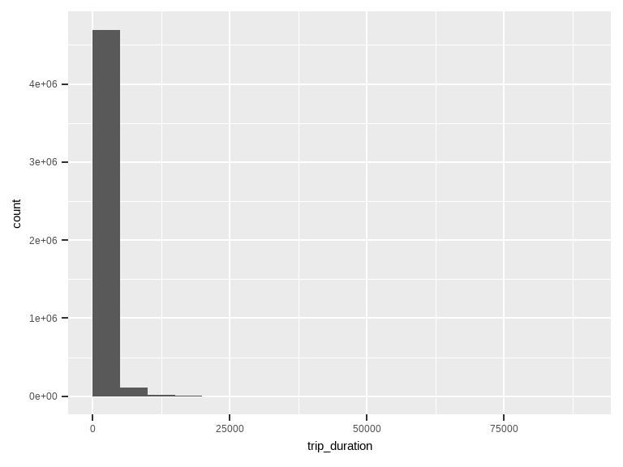

- Note that the following possible outlier values were detected: "60", "61", "62", "63", "64", …, "86373", "86383", "86390", "86391", "86394" (17757 values omitted).

## month

| Feature | Result |
| --- | --- |
| Variable type | factor |
| Number of missing obs. | 0 (0 %) |
| Number of unique values | 12 |
| Mode | “7” |
| Reference category | 1 |

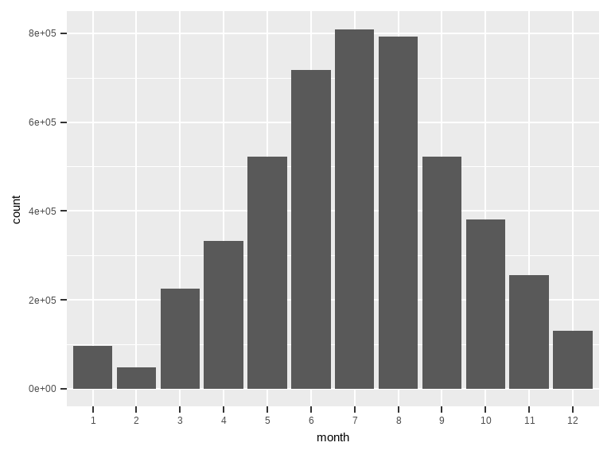

- Note: The variable consists exclusively of numbers and takes a lot of different values. Is it perhaps a misclassified numeric variable?

## day

| Feature | Result |
| --- | --- |
| Variable type | factor |
| Number of missing obs. | 0 (0 %) |
| Number of unique values | 31 |
| Mode | “7” |
| Reference category | 1 |

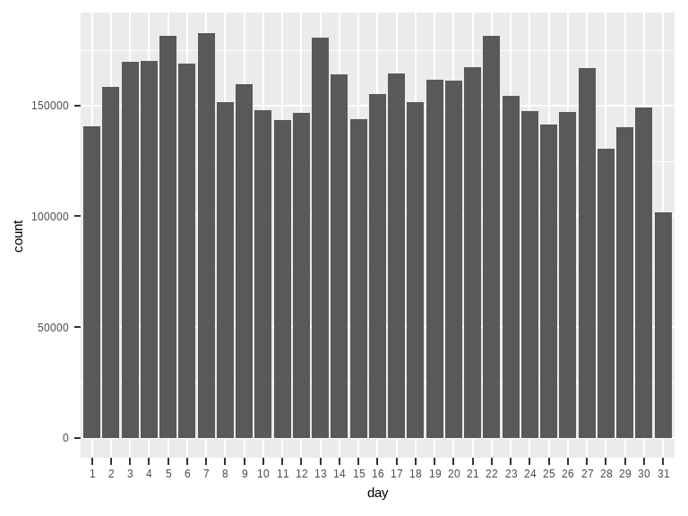

- Note: The variable consists exclusively of numbers and takes a lot of different values. Is it perhaps a misclassified numeric variable?

## day_of_week

| Feature | Result |
| --- | --- |
| Variable type | factor |
| Number of missing obs. | 0 (0 %) |
| Number of unique values | 7 |
| Mode | “SATURDAY” |
| Reference category | FRIDAY |

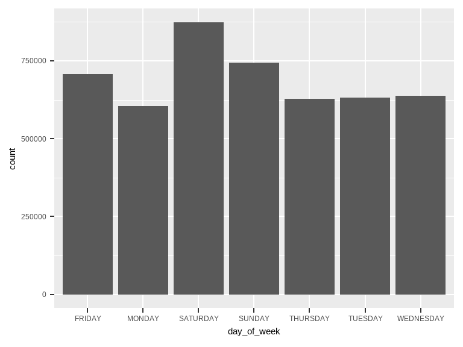

## bike_type

| Feature | Result |
| --- | --- |
| Variable type | factor |
| Number of missing obs. | 0 (0 %) |
| Number of unique values | 3 |
| Mode | “CLASSIC” |
| Reference category | CLASSIC |

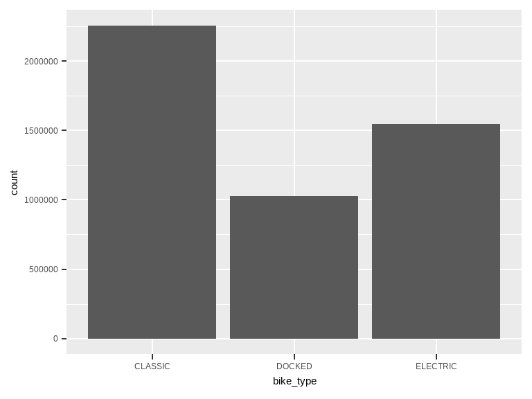

## start_station

| Feature | Result |
| --- | --- |
| Variable type | factor |
| Number of missing obs. | 0 (0 %) |
| Number of unique values | 1151 |
| Mode | “STREETER DR & GRAND AVE” |
| Reference category | 100TH PLACE |

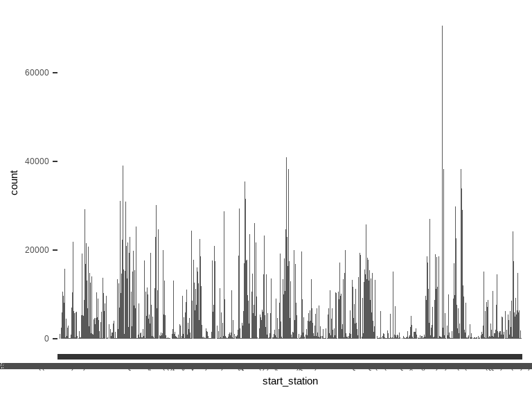

- Note that the following levels have at most five observations: "129TH STREET", "139TH PLACE", "13TH STREET", "15TH STREET", "28TH STREET", …, "WEST FOREST PRESERVE DRIVE", "WEST GROVER STREET", "WEST HOWARD STREET", "WEST IRVING PARK ROAD", "WILLIAM STREET" (55 values omitted).

## end_station

| Feature | Result |
| --- | --- |
| Variable type | factor |
| Number of missing obs. | 3020 (0.06 %) |
| Number of unique values | 1271 |
| Mode | “STREETER DR & GRAND AVE” |
| Reference category | 100TH PLACE |

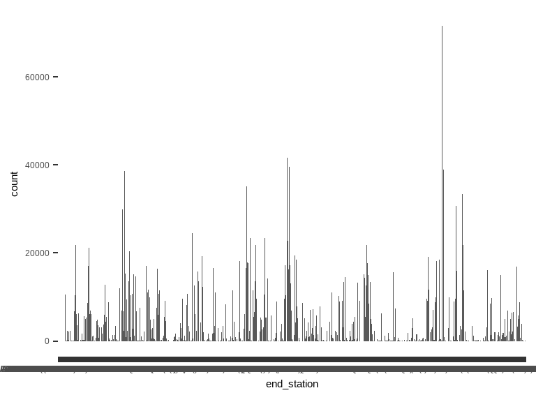

- Note that the following levels have at most five observations: "129TH STREET", "136TH STREET", "139TH PLACE", "145TH STREET", "15TH STREET", …, "WHITING", "WIND POINT COURT", "WISCONSIN AVENUE", "WOLF LAKE MEMORIAL TRAIL", "WOODS DRIVE" (157 values omitted).

## start_lat

| Feature | Result |
| --- | --- |
| Variable type | numeric |
| Number of missing obs. | 0 (0 %) |
| Number of unique values | 359016 |
| Median | 41.9 |
| 1st and 3rd quartiles | 41.88; 41.93 |
| Min. and max. | 41.64; 42.08 |

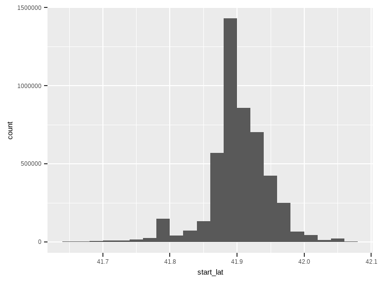

- Note that the following possible outlier values were detected: "41.64", "41.65", "41.65", "41.65", "41.65", …, "42.06", "42.06", "42.06", "42.07", "42.08" (41973 values omitted).

## start_lng

| Feature | Result |
| --- | --- |
| Variable type | numeric |
| Number of missing obs. | 0 (0 %) |
| Number of unique values | 341540 |
| Median | -87.64 |
| 1st and 3rd quartiles | -87.66; -87.63 |
| Min. and max. | -87.84; -87.52 |

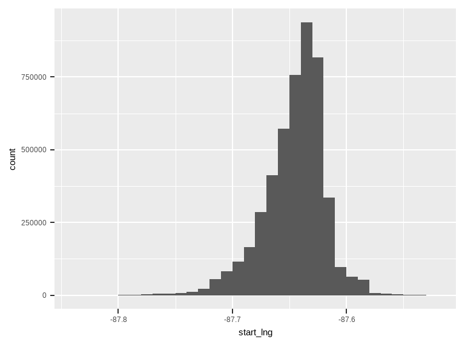

- Note that the following possible outlier values were detected: "-87.84", "-87.83", "-87.82", "-87.81", "-87.8", …, "-87.53", "-87.53", "-87.53", "-87.53", "-87.52" (22662 values omitted).

## end_lat

| Feature | Result |
| --- | --- |
| Variable type | numeric |
| Number of missing obs. | 3020 (0.06 %) |
| Number of unique values | 420985 |
| Median | 41.9 |
| 1st and 3rd quartiles | 41.88; 41.93 |
| Min. and max. | 41.51; 42.15 |

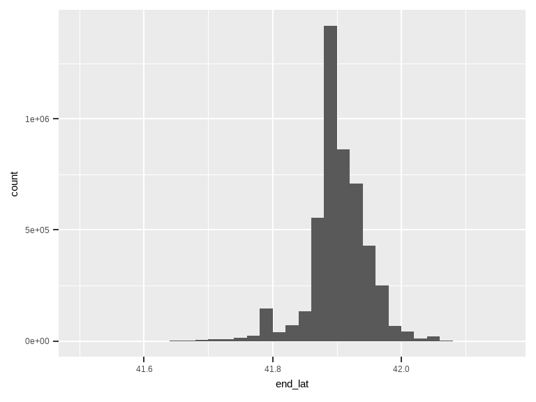

- Note that the following possible outlier values were detected: "41.51", "41.54", "41.56", "41.58", "41.59", …, "42.11", "42.12", "42.13", "42.14", "42.15" (44039 values omitted).

## end_lng

| Feature | Result |
| --- | --- |
| Variable type | numeric |
| Number of missing obs. | 3020 (0.06 %) |
| Number of unique values | 385027 |
| Median | -87.64 |
| 1st and 3rd quartiles | -87.66; -87.63 |
| Min. and max. | -88.07; -87.44 |

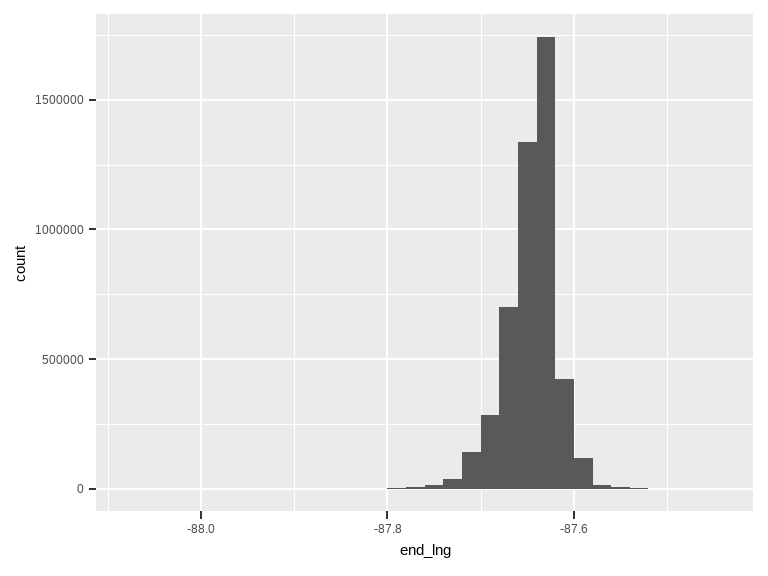

- Note that the following possible outlier values were detected: "-88.07", "-87.88", "-87.87", "-87.86", "-87.85", …, "-87.52", "-87.51", "-87.5", "-87.49", "-87.44" (24946 values omitted).

## user_type

| Feature | Result |
| --- | --- |
| Variable type | factor |
| Number of missing obs. | 0 (0 %) |
| Number of unique values | 2 |
| Mode | “MEMBER” |
| Reference category | CASUAL |

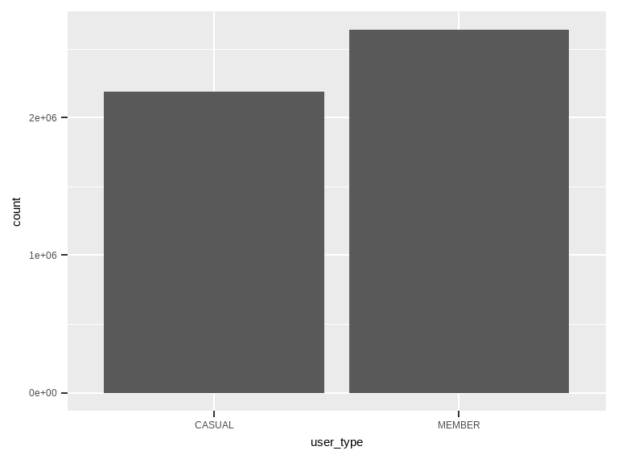

## heat_index

| Feature | Result |
| --- | --- |
| Variable type | numeric |
| Number of missing obs. | 0 (0 %) |
| Number of unique values | 1342 |
| Median | 22.41 |
| 1st and 3rd quartiles | 14.01; 27.07 |
| Min. and max. | -21.11; 40.24 |

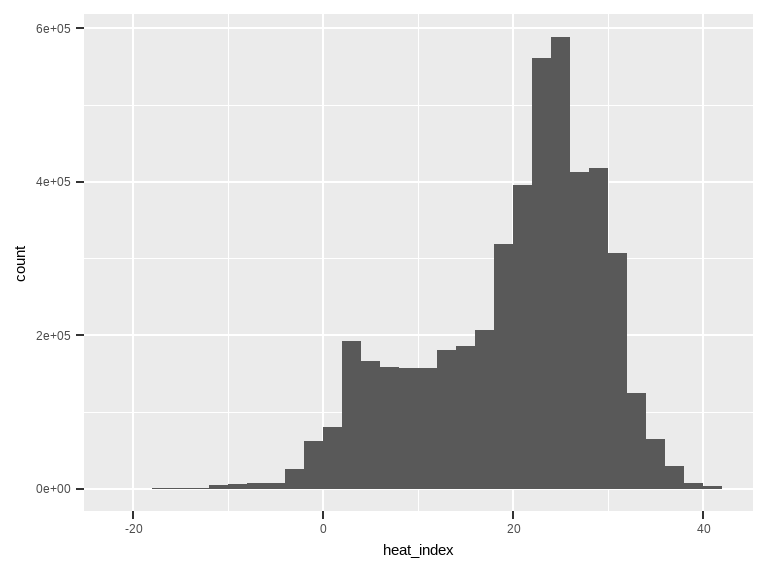

- Note that the following possible outlier values were detected: "32.72", "32.74", "32.77", "32.84", "32.89", …, "38.83", "39.13", "39.51", "39.55", "40.24" (45 values omitted).

## dew_point

| Feature | Result |
| --- | --- |
| Variable type | numeric |
| Number of missing obs. | 0 (0 %) |
| Number of unique values | 93 |
| Median | 11.67 |
| 1st and 3rd quartiles | 3.33; 17.22 |
| Min. and max. | -26.67; 24.44 |

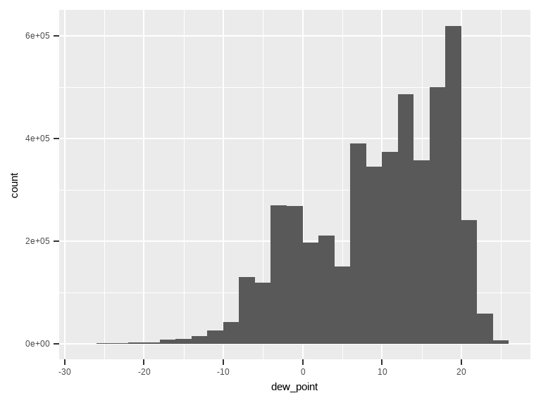

## drybulb_temperature

| Feature | Result |
| --- | --- |
| Variable type | numeric |
| Number of missing obs. | 0 (0 %) |
| Number of unique values | 102 |
| Median | 22.78 |
| 1st and 3rd quartiles | 15; 26.67 |
| Min. and max. | -21.11; 35 |

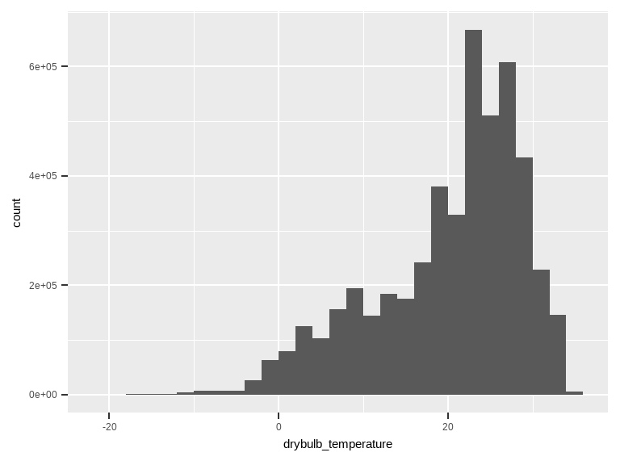

- Note that the following possible outlier values were detected: "31.67", "32.22", "32.78", "33.33", "33.89", "34.44", "35".

## precipitation

| Feature | Result |
| --- | --- |
| Variable type | numeric |
| Number of missing obs. | 479692 (9.93 %) |
| Number of unique values | 50 |
| Median | 0 |
| 1st and 3rd quartiles | 0; 0 |
| Min. and max. | 0; 22.1 |

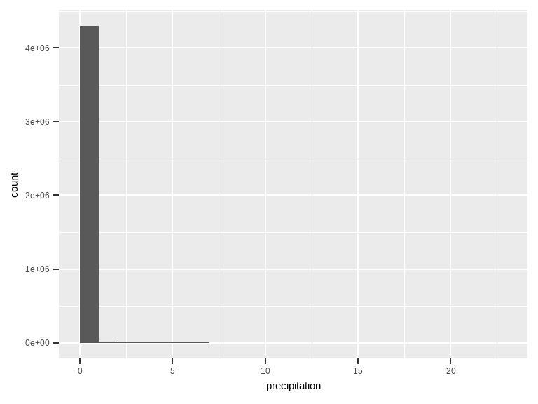

- Note that the following possible outlier values were detected: "0.13", "0.25", "0.51", "0.76", "1.02", …, "18.54", "18.8", "20.57", "21.08", "22.1" (39 values omitted).

## humidity

| Feature | Result |
| --- | --- |
| Variable type | integer |
| Number of missing obs. | 0 (0 %) |
| Number of unique values | 82 |
| Median | 53 |
| 1st and 3rd quartiles | 41; 65 |
| Min. and max. | 16; 100 |

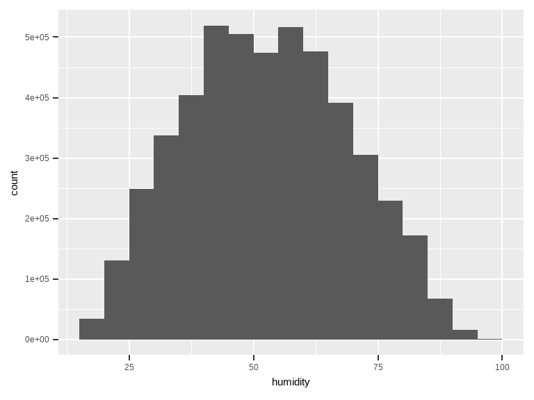

## wetbulb_temperature

| Feature | Result |
| --- | --- |
| Variable type | numeric |
| Number of missing obs. | 619 (0.01 %) |
| Number of unique values | 88 |
| Median | 16.67 |
| 1st and 3rd quartiles | 9.44; 20 |
| Min. and max. | -21.67; 26.67 |

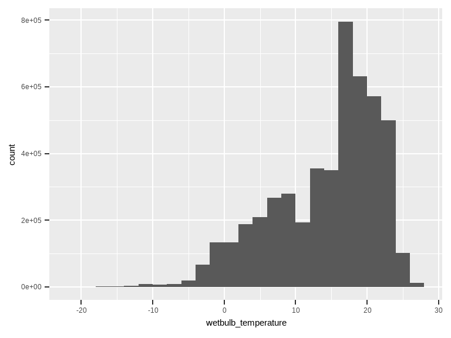

- Note that the following possible outlier values were detected: "24.44", "25", "25.56", "26.11", "26.67".

## wind_direction

| Feature | Result |
| --- | --- |
| Variable type | integer |
| Number of missing obs. | 9856 (0.2 %) |
| Number of unique values | 38 |
| Median | 200 |
| 1st and 3rd quartiles | 80; 240 |
| Min. and max. | 0; 999 |

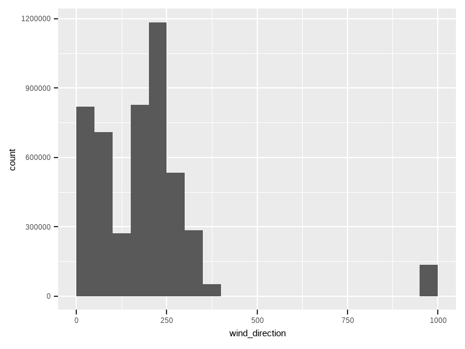

- The following suspected missing value codes enter as regular values: "999".
- Note that the following possible outlier values were detected: "320", "330", "340", "350", "360", "999".

## wind_speed

| Feature | Result |
| --- | --- |
| Variable type | numeric |
| Number of missing obs. | 51 (0 %) |
| Number of unique values | 32 |
| Median | 16.1 |
| 1st and 3rd quartiles | 11.27; 20.94 |
| Min. and max. | 0; 62.81 |

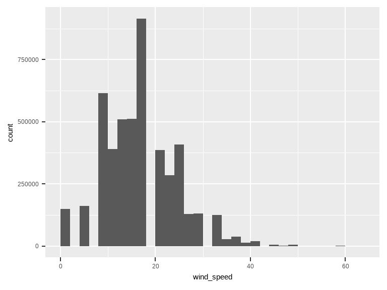

- Note that the following possible outlier values were detected: "0", "45.09", "46.7", "48.31", "49.92", …, "53.14", "57.98", "59.59", "61.2", "62.81" (1 values omitted).

Report generation information:

- Created by: Could not determine from system (username: Unknown)
- Report creation time: Wed Feb 02 2022 12:21:39
- Report was run from directory: `C:/Users/renal/OneDrive/Documents`
- dataMaid v1.4.1 [Pkg: 2021-10-08 from CRAN (R 4.1.2)]
- R version 4.1.2 (2021-11-01).
- Platform: x86_64-w64-mingw32/x64 (64-bit)(Windows 10 x64 (build 22000)).
- Function call: `makeDataReport(data = bike_data, output = "html", render = TRUE, useVar = NULL, ordering = c("asIs"), onlyProblematic = FALSE, labelled_as = c("factor"), mode = c("summarize", "visualize", "check"), smartNum = TRUE, preChecks = c("isKey", "isSingular", "isSupported"), file = "EDA_Report_Cyclistic.Rmd", replace = FALSE, vol = "", standAlone = TRUE, twoCol = FALSE, quiet = TRUE, openResult = TRUE, summaries = setSummaries(), visuals = setVisuals(), checks = setChecks(), listChecks = TRUE, maxProbVals = 10, maxDecimals = 2, addSummaryTable = TRUE, codebook = FALSE, reportTitle = "EDA Report Cyclistic", treatXasY = NULL, includeVariableList = TRUE)`